# Divvy Cyclist Trip Case Study

Kevin Banh

1/17/2022

# Introduction

[figure not shown]

In this case study, we will be focusing on Divvy, a program of the Chicago Department of Transportation and operated by LYFT, focused on providing bikes for users to rent and ride around the city. The service allows users to rent bikes from one station and return it at any other Divvy station. Using secondary data collected by Divvy themselves which was updated on January 6th, 2022, analysis will be done to answer key questions to help Divvy restructure their ad campaign.

# Business Task

We are interested in restructuring Divvy’s ad campaign to better target and transition casual riders to become Divvy members. Casual riders are people who buy the single-ride pass and the full day pass while Divvy members purchase the annual memberships.

The key business questions that will help us achieve our task are:

1. What is the difference in the riding habits between casual riders and Divvy members?
2. Why would casual riders choose the annual memberships?
3. How can Divvy restructure its marketing program to influence casual riders to become members?

# Data Sources

We will be using the data source https://divvy-tripdata.s3.amazonaws.com/index.html provided by Divvy. We will be using data over the course of 12 months during 2021.

This data source was provided by Divvy. All bike riders are identified by their unique ride_id # thus there is no bias towards one group.

Some important things to note is that Divvy has removed all bike rides that are less than 60 seconds to eliminate riders who are just having issues docking their bike i.e having a false start in addition to trips made by their own employees. It is possible that people have spent more than 60 seconds since we don’t have any data on this thus our data might not be as credible.

Since this data is updated monthly and is very recent, our analysis will be accurate for the business task at hand.

# Necessary libraries

```r
# Packages to connect to BigQuery
library(bigrquery)
library(DBI)

# Data processing and manipulation
library(dplyr)
library(plyr)
```

```r
library(readr)
library(sjmisc)

# Data visualizations
library(ggplot2)
library(RColorBrewer)
```

# Getting our data

## Merging all 12 months of data

```r
# Merge all of our csv files over the course of 12 months into one csv file
cyclist <- list.files(path = "C:\\Users\\kevin\\OneDrive\\Documents\\Portfolio Projects\\Google Analytics\\Capstone",
                       pattern = "*.csv", full.names = TRUE) %>%
  lapply(read_csv) %>%
  bind_rows()
```

# Data Cleaning

```r
glimpse(cyclist)
```

[output not shown]

Another problem is **start_station_name**, **start_station_id**, and **end_station_name**, **end_station_id**. These attributes from a glance already have quite a bit of null values so we might delete these attributes all together since we don’t need them to answer our business question.

The identification attributes (**ride_id**, **start_station_id**, **end_station_id**) should be factors as these are unique identifiers.

```r
# Convert to dataframe
cyclist_df <- cyclist %>%
  as.data.frame()

# ride_id must be 16 characters
cyclist_df %>%
  filter(nchar(ride_id) > 16)
```

```r
# Convert started_at and ended_at from date time to date
dates_to_convert <- c("started_at", "ended_at")

# Hold time portion of datetime
time_started <- format(cyclist_df$started_at, "%H:%M:%S")
time_ended <- format(cyclist_df$ended_at, "%H:%M:%S")

# Hold date portions of datetime
date_started <- as.Date(cyclist_df$started_at)
date_ended <- as.Date(cyclist_df$ended_at)


# Add these new split date and time variables and delete the pre-existing ones as well as ...1 column
cyclist_df <- cyclist_df %>%
  mutate(time_started = time_started,
         time_ended = time_ended,
         date_started = date_started,
         date_ended = date_ended) %>%
  select(-c("started_at", "ended_at"))


glimpse(cyclist_df)
```

```r
for(i in 1:dim(cyclist_df)[2]){
  # If character field then check if string is empty (trim string first)
  # If numeric then check if na or NaN value
  # Sum all of the values and print out
  col = cyclist_df[,i]
  is.date <- function(x) inherits(x, 'date') # Check if class is Date
  print(paste0(names(cyclist_df)[i], ": ",ifelse(is.numeric(col),
                                                  sum(is.na(col)),
                                                  ifelse(is.character(col),
                                                         count(col == "NA")[2,2], #[2,2] index shows the # of TRUEs there are. NA means no NA values
                                                         ifelse(is.date(col),
                                                                count(trimws(col) == "")[2,2],
                                                                "No null/empty values found")))))
}
```

[output not shown]

```r
# Remove columns containing we found that have too many NA values
cyclist_df[, c("start_station_name", "start_station_id", "end_station_name", "end_station_id")] <- list(NULL)

# Remove entire records containing end_lat and end_lng NA values
cyclist_df <- cyclist_df[!is.na(cyclist_df$end_lat) & !is.na(cyclist_df$end_lng),]

# Verify that these values are gone
count(is.na(cyclist_df$end_lat) & is.na(cyclist_df$end_lng))

glimpse(cyclist_df)
```

```r
# Find duplicates
sum(duplicated(cyclist_df))
```

```r
# Write a csv file for our merged data
write.csv(cyclist_df, file = "2021-divvy-tripdata.csv")
```

# Add our data to BigQuery database

Before adding our data to our BigQuery, we will need to store this csv file in a Google Cloud Storage bucket due to the size being too large. After we’ve done so, import our data into a table in the database.

# Connect to our BigQuery database

```r
# Establish connection to our database
con <- dbConnect(
  bigrquery::bigquery(),
  project = "portfolio-projects-338303",
  dataset = "cyclist_trip",
  billing = "portfolio-projects-338303"
)

# Find all of the tables in the database
dbListTables(con)
```

[output not shown]

[output not shown]

[output not shown]

[output not shown]

```
## [1] "2021_divvy_tripdata"
```

```r
cyclist <- dplyr::tbl(con, "2021_divvy_tripdata")
```

# EDA

```r
num_riders_mem_casual <- dbGetQuery(con,
           "SELECT DISTINCT member_casual, COUNT(*) as num_riders
            FROM `portfolio-projects-338303.cyclist_trip.2021_divvy_tripdata`
            GROUP BY member_casual")
```

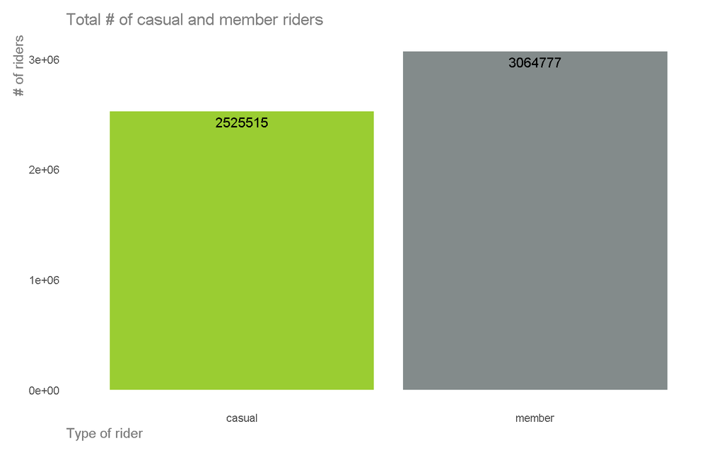

```r
num_riders_mem_casual %>%
  ggplot(aes(x = member_casual, y = num_riders, fill = member_casual)) +
  geom_bar(stat = "identity") +
  geom_text(aes(label = num_riders), vjust = 1.5, color = "black") +
  scale_fill_manual(values = c("olivedrab3", "azure4")) +
  labs(title = "Total # of casual and member riders") +
  theme(legend.position = "none",
        axis.ticks.y = element_blank(),
        axis.ticks.x = element_blank(),
        panel.background = element_blank(),
        axis.title.x = element_text(hjust = 0),
        axis.title.y = element_text(hjust = 1),
        axis.title = element_text(color = "#808080"),
        plot.title = element_text(color = "#808080"),
        plot.margin = margin(t = 10, b = 10, l = 10, r = 10)) +
  xlab("Type of rider") +
  ylab("# of riders")
```

There are more Divvy members (members who purchased the annual membership) than casual members who buy a one-time or 24-hour pass.

```r
bike_type_member <- dbGetQuery(con,
           "SELECT
                  member_casual,
                  rideable_type,
                  COUNT(*)/(SELECT COUNT(*)
                            FROM `portfolio-projects-338303.cyclist_trip.2021_divvy_tripdata`
                            WHERE member_casual = 'member') as percentage_riders
            FROM `portfolio-projects-338303.cyclist_trip.2021_divvy_tripdata`
            WHERE member_casual = 'member'
            GROUP BY rideable_type, member_casual")
```

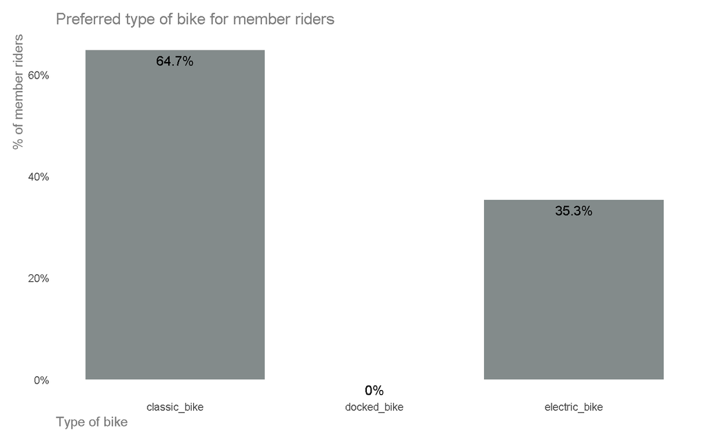

```r
bike_type_member %>%
  ggplot(aes(x = rideable_type, y = percentage_riders, fill = member_casual)) +
  geom_bar(stat = "identity") +
  geom_text(aes(label = paste0(round(percentage_riders*100,1), "%")), vjust = 1.5, color = "black") +
  scale_y_continuous(labels = function(x) paste0(x*100, "%")) +
  scale_fill_manual(values = "azure4") +
  labs(title = "Preferred type of bike for member riders") +
  theme(legend.position = "none",
        axis.ticks.x = element_blank(),
        axis.title.x = element_text(hjust = 0),
        axis.title.y = element_text(hjust = 1),
        axis.ticks.y = element_blank(),
        panel.background = element_blank(),
        axis.title = element_text(color = "#808080"),
        plot.title = element_text(color = "#808080"),
        plot.margin = margin(t = 10, b = 10, l = 10, r = 10)) +
  xlab("Type of bike") +
  ylab("% of member riders")
```

```r
bike_type_casual <- dbGetQuery(con,
           "SELECT
                  member_casual,
                  rideable_type,
                  COUNT(*)/(SELECT COUNT(*)
                            FROM `portfolio-projects-338303.cyclist_trip.2021_divvy_tripdata`
                            WHERE member_casual = 'casual') as percentage_riders
            FROM `portfolio-projects-338303.cyclist_trip.2021_divvy_tripdata`
            WHERE member_casual = 'casual'
            GROUP BY rideable_type, member_casual")
```

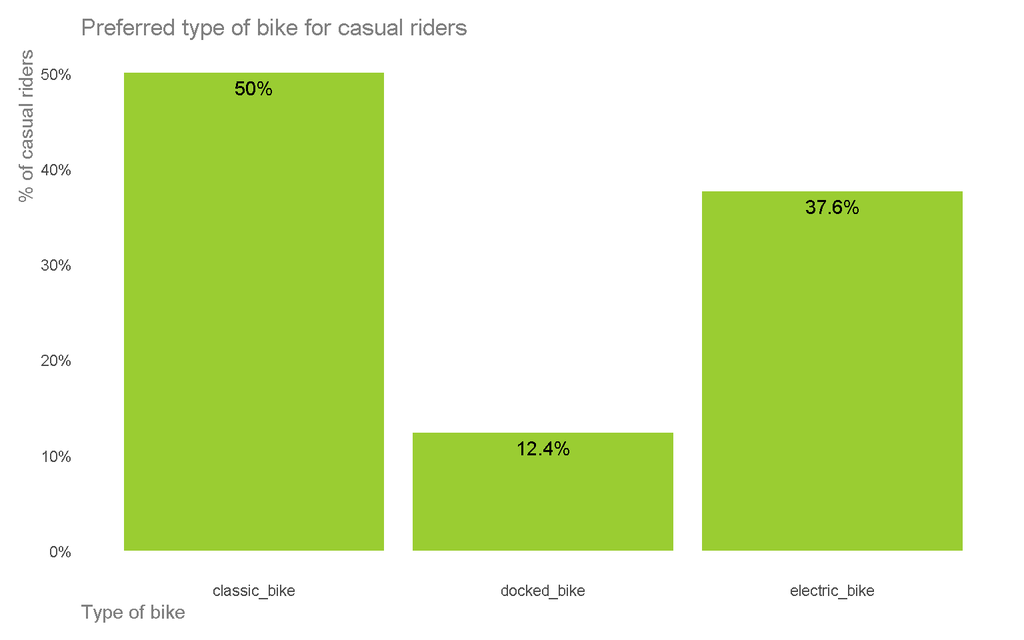

```r
bike_type_casual %>%
  ggplot(aes(x = rideable_type, y = percentage_riders, fill = member_casual)) +
  geom_bar(stat = "identity") +
  geom_text(aes(label = paste0(round(percentage_riders*100,1), "%")), vjust = 1.5, color = "black") +
  scale_y_continuous(labels = function(x) paste0(x*100, "%")) +
  scale_fill_manual(values = "olivedrab3") +
  labs(title = "Preferred type of bike for casual riders") +
  theme(legend.position = "none",
        axis.title.x = element_text(hjust = 0),
        axis.title.y = element_text(hjust = 1),
        axis.ticks.x = element_blank(),
        axis.ticks.y = element_blank(),
        panel.background = element_blank(),
        axis.title = element_text(color = "#808080"),
        plot.title = element_text(color = "#808080"),
        plot.margin = margin(t = 10, b = 10, l = 10, r = 10)) +
  xlab("Type of bike") +
  ylab("% of casual riders")
```

```r
mem_casual_bike <- dbGetQuery(con,
           "SELECT member_casual, rideable_type, COUNT(*) as num_riders
            FROM `portfolio-projects-338303.cyclist_trip.2021_divvy_tripdata`
            GROUP BY rideable_type, member_casual")
```

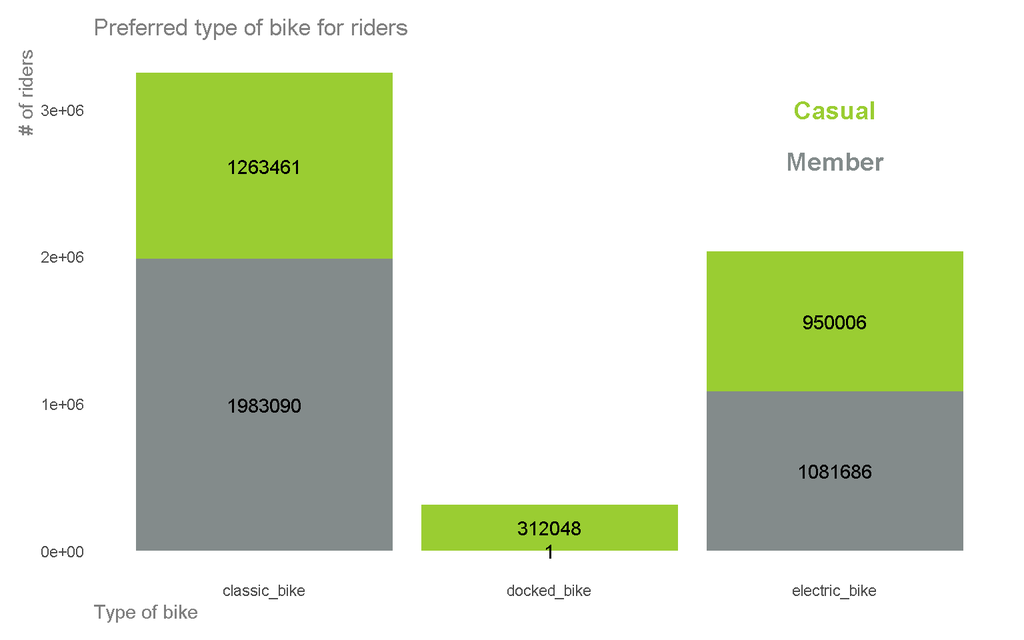

```r
mem_casual_bike %>%
  ggplot(aes(x = rideable_type, y = num_riders, fill = member_casual)) +
  geom_bar(stat = "identity") +
  geom_text(aes(label = num_riders), color = "black",position = position_stack(vjust = .5)) +
  scale_fill_manual(values = c("olivedrab3", "azure4")) +
  labs(title = "Preferred type of bike for riders") +
  theme(legend.position = "none",
        axis.title.x = element_text(hjust = 0),
        axis.title.y = element_text(hjust = 1),
        axis.ticks.x = element_blank(),
        axis.ticks.y = element_blank(),
        panel.background = element_blank(),
        axis.title = element_text(color = "#808080"),
        plot.title = element_text(color = "#808080"),
        plot.margin = margin(t = 10, b = 10, l = 10, r = 10)) +
  xlab("Type of bike") +
  ylab("# of riders") +
  annotate("text", x = 3, y = 3000000, label = "Casual", color = "olivedrab3", size = 5, fontface = 2) +
  annotate("text", x = 3, y = 2650000, label = "Member", color = "azure4", size = 5, fontface = 2)
```

```r
distance_table <- dbGetQuery(con,
                             "WITH output_1 AS (
                                SELECT
                                  ST_GEOGPOINT(start_station.start_lat, start_station.start_lng) AS start,
                                  start_station.member_casual,
                                  ST_GEOGPOINT(SAFE_CAST(end_station.end_lat AS FLOAT64), SAFE_CAST(end_station.end_lng AS FLOAT64)) AS end_stat,
                                  ST_DISTANCE(ST_GEOGPOINT(start_station.start_lat,start_station.start_lng),
                                              ST_GEOGPOINT(SAFE_CAST(end_station.end_lat AS FLOAT64), SAFE_CAST(end_station.end_lng AS FLOAT64)))
                                              AS total_distance_traveled
                                FROM
                                  `portfolio-projects-338303.cyclist_trip.2021_divvy_tripdata` AS start_station
                                JOIN
                                  `portfolio-projects-338303.cyclist_trip.2021_divvy_tripdata` AS end_station
                                ON start_station.ride_id = end_station.ride_id
                                WHERE end_station.end_lat IS NOT NULL
                                AND end_station.end_lng IS NOT NULL)

                                SELECT
                                  DISTINCT member_casual,
                                  AVG(total_distance_traveled) as average_distance_traveled
                                FROM output_1
                                GROUP BY member_casual")
```

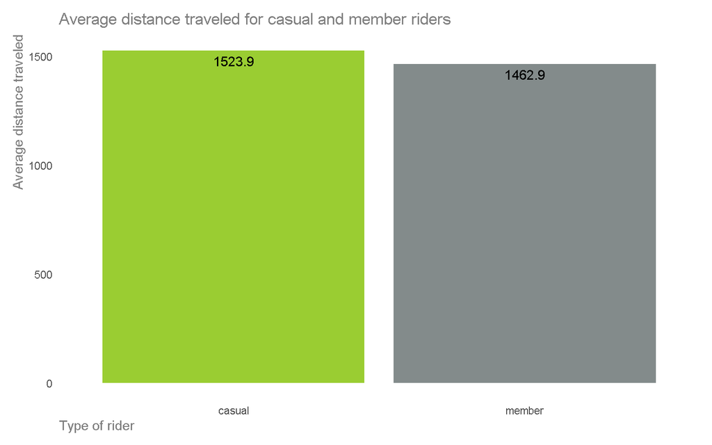

```r
distance_table %>%
  ggplot(aes(x = member_casual, y = average_distance_traveled, fill = member_casual)) +
  geom_bar(stat = "identity")+
  geom_text(aes(label = round(average_distance_traveled, 1)), vjust = 1.5, color = "black") +
  scale_fill_manual(values = c("olivedrab3", "azure4")) +
  labs(title = "Average distance traveled for casual and member riders") +
  theme(legend.position = "none",
        axis.title.x = element_text(hjust = 0),
        axis.title.y = element_text(hjust = 1),
        axis.ticks.x = element_blank(),
        axis.ticks.y = element_blank(),
        panel.background = element_blank(),
        axis.title = element_text(color = "#808080"),
        plot.title = element_text(color = "#808080"),
        plot.margin = margin(t = 10, b = 10, l = 10, r = 10)) +
  xlab("Type of rider") +
  ylab("Average distance traveled")
```

Surprisingly, casual riders travel longer distances on average than members. Perhaps members use bikes on short trips more frequently than casual riders who are possibly tourists who will travel longer distances.

```r
weekly_riders <- dbGetQuery(con,
           "SELECT
              FORMAT_DATE('%a', date_started) as weekday_started,
              COUNT(*) as num_riders,
              member_casual
            FROM `portfolio-projects-338303.cyclist_trip.2021_divvy_tripdata`
            GROUP BY weekday_started, member_casual
            ORDER BY
              CASE
                WHEN weekday_started = 'Sun' THEN 1
                WHEN weekday_started = 'Mon' THEN 2
                WHEN weekday_started = 'Tue' THEN 3
                WHEN weekday_started = 'Wed' THEN 4
                WHEN weekday_started = 'Thu' THEN 5
                WHEN weekday_started = 'Fri' THEN 6
                WHEN weekday_started = 'Sat' THEN 7
              END ASC
            "
           )
```

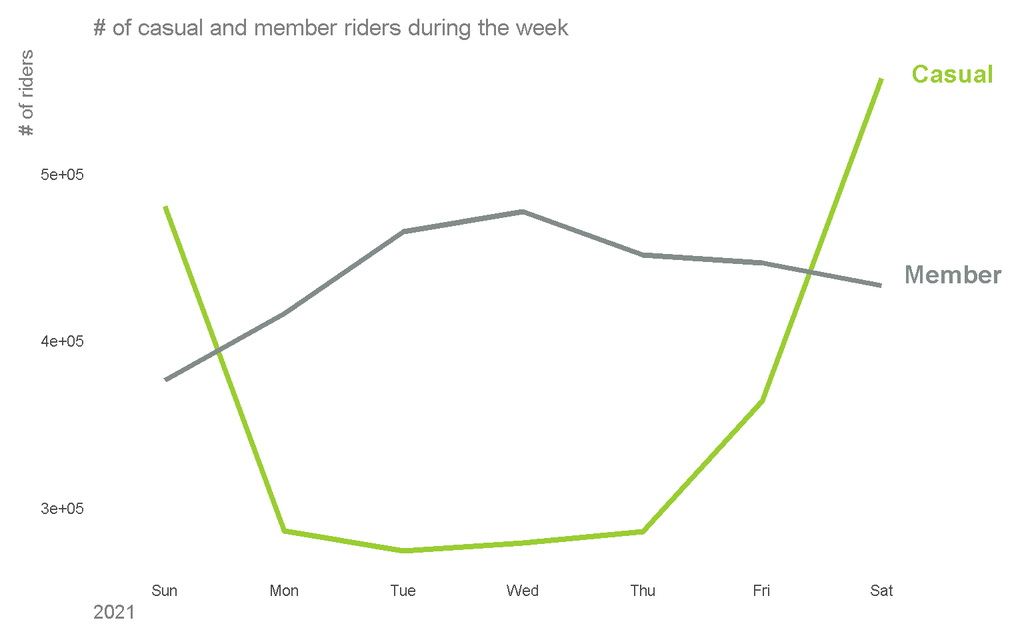

```r
weekly_riders %>%
  ggplot(aes(x = factor(weekday_started, levels = unique(weekday_started)), y = num_riders, group = member_casual, color = member_casual)) +
  geom_line(size = 1.5) +
  scale_color_manual(values = c("olivedrab3", "azure4")) +
  theme(axis.title.x = element_text(hjust = 0),
        axis.title.y = element_text(hjust = 1),
        axis.ticks.x = element_blank(),
        axis.ticks.y = element_blank(),
        legend.position = "none",
        panel.background = element_blank(),
        plot.margin = margin(t = 10, b = 10, l = 10, r = 40),
        axis.title = element_text(color = "#808080"),
        plot.title = element_text(color = "#808080")) +
  annotate("text", x = 7.6, y = 440000, label = "Member", color = "azure4", size = 5, fontface = 2) +
  annotate("text", x = 7.6, y = 560000, label = "Casual", color = "olivedrab3", size = 5, fontface = 2) +
  labs(title = "# of casual and member riders during the week", y = "# of riders") +
  xlab("2021") +
  coord_cartesian(clip = "off")
```

Member riders have a steady amount of trips throughout the week while casual riders have very low periods during the week while having their peak periods during the weekend.

```r
monthly_riders <- dbGetQuery(con,
           "SELECT
              FORMAT_DATE('%b', date_started) as month_started,
              COUNT(*) as num_riders,
              member_casual
            FROM `portfolio-projects-338303.cyclist_trip.2021_divvy_tripdata`
            GROUP BY month_started, member_casual
            ORDER BY
              CASE
                WHEN month_started = 'Jan' THEN 1
                WHEN month_started = 'Feb' THEN 2
                WHEN month_started = 'Mar' THEN 3
                WHEN month_started = 'Apr' THEN 4
                WHEN month_started = 'May' THEN 5
                WHEN month_started = 'Jun' THEN 6
                WHEN month_started = 'Jul' THEN 7
                WHEN month_started = 'Aug' THEN 8
                WHEN month_started = 'Sep' THEN 9
                WHEN month_started = 'Oct' THEN 10
                WHEN month_started = 'Nov' THEN 11
                WHEN month_started = 'Dec' THEN 12
              END ASC")
```

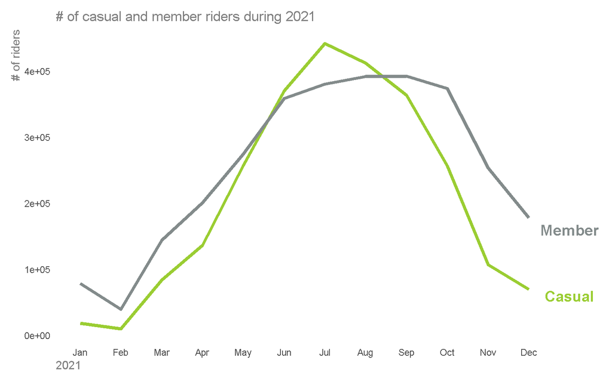

```r
monthly_riders %>%
  ggplot(aes(x = factor(month_started, levels = unique(month_started)), y = num_riders, group = member_casual, color = member_casual)) +
  geom_line(size = 1.5) +
  scale_color_manual(values = c("olivedrab3", "azure4")) +
  theme(axis.title.x = element_text(hjust = 0),
        axis.title.y = element_text(hjust = 1),
        legend.position = "none",
        plot.margin = margin(t = 10, b = 10, l = 10, r = 40),
        panel.background = element_blank(),
        axis.ticks.x = element_blank(),
        axis.ticks.y = element_blank(),
        axis.title = element_text(color = "#808080"),
        plot.title = element_text(color = "#808080")) +
  annotate("text", x = 13, y = 160000, label = "Member", color = "azure4", size = 5, fontface = 2) +
  annotate("text", x = 13, y = 60000, label = "Casual", color = "olivedrab3", size = 5, fontface = 2) +
  labs(title = "# of casual and member riders during 2021", y = "# of riders") +
  xlab("2021") +
  coord_cartesian(clip = "off")
```

```r
total_distance_yearly <- dbGetQuery(con,
            "WITH output_1 AS (
                SELECT
                  FORMAT_DATE('%b', start_station.date_started) as month_started,
                  start_station.member_casual as member_casual,
                  ST_DISTANCE(ST_GEOGPOINT(start_station.start_lat,start_station.start_lng),
                              ST_GEOGPOINT(SAFE_CAST(end_station.end_lat AS FLOAT64), SAFE_CAST(end_station.end_lng AS FLOAT64)))
                              AS total_distance_traveled
                FROM
                  `portfolio-projects-338303.cyclist_trip.2021_divvy_tripdata` AS start_station
                JOIN
                  `portfolio-projects-338303.cyclist_trip.2021_divvy_tripdata` AS end_station
                ON start_station.ride_id = end_station.ride_id)

                SELECT
                  month_started,
                  member_casual,
                  ROUND(AVG(total_distance_traveled), 1) as total_distance_traveled
                  FROM output_1
                  GROUP BY month_started, member_casual
                  ORDER BY
                    CASE
                      WHEN month_started = 'Jan' THEN 1
                      WHEN month_started = 'Feb' THEN 2
                      WHEN month_started = 'Mar' THEN 3
                      WHEN month_started = 'Apr' THEN 4
                      WHEN month_started = 'May' THEN 5
                      WHEN month_started = 'Jun' THEN 6
                      WHEN month_started = 'Jul' THEN 7
                      WHEN month_started = 'Aug' THEN 8
                      WHEN month_started = 'Sep' THEN 9
                      WHEN month_started = 'Oct' THEN 10
                      WHEN month_started = 'Nov' THEN 11
                      WHEN month_started = 'Dec' THEN 12
                      END ASC")
```

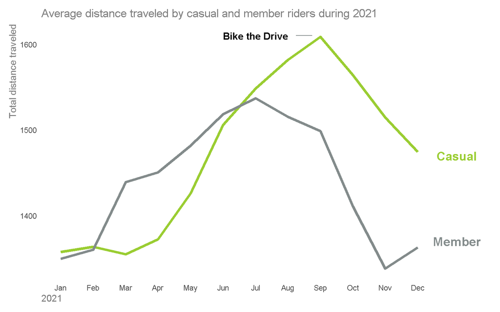

```r
total_distance_yearly %>%
  ggplot(aes(x = factor(month_started, levels = unique(month_started)), y = total_distance_traveled, group = member_casual, color = member_casual)) +
  geom_line(size = 1.5) +
  scale_color_manual(values = c("olivedrab3", "azure4")) +
  theme(axis.title.x = element_text(hjust = 0),
        axis.title.y = element_text(hjust = 1),
        axis.ticks.x = element_blank(),
        axis.ticks.y = element_blank(),
        legend.position = "none",
        plot.margin = margin(t = 10, b = 10, l = 10, r = 50),
        panel.background = element_blank(),
        axis.title = element_text(color = "#808080"),
        plot.title = element_text(color = "#808080")) +
  annotate("text",
           x = 13.2,
           y = 1370,
           label = "Member",
           color = "azure4",
           size = 5,
           fontface = 2) +
  annotate("text",
           x = 13.2,
           y = 1470,
           label = "Casual",
           color = "olivedrab3",
           size = 5,
           fontface = 2) +
  annotate("text",
           x = 7,
           y = 1610,
           label = "Bike the Drive",
           size = 4,
           fontface = 2) +
  geom_segment(aes(x = 8.25,
                   y = 1610,
                   xend = 8.75,
                   yend = 1610)) +
  labs(title = "Average distance traveled by casual and member riders during 2021", y = "Total distance traveled") +
  scale_x_discrete(drop=FALSE) +
  coord_cartesian(clip = "off") +
  xlab("2021")
```

```r
time_of_day <- dbGetQuery(con,
           "SELECT
              FORMAT_DATE('b', date_started) as week_started,
              member_casual,
              CASE
                WHEN EXTRACT(HOUR FROM time_started) BETWEEN 5 AND 12 THEN 'Morning'
                WHEN EXTRACT(HOUR FROM time_started) BETWEEN 13 AND 17 THEN 'Afternoon'
                WHEN EXTRACT(HOUR FROM time_started) BETWEEN 18 AND 21 THEN 'Evening'
                ELSE 'Night'
              END AS ride_part_of_the_day
            FROM `portfolio-projects-338303.cyclist_trip.2021_divvy_tripdata`
            GROUP BY date_started, member_casual, time_started
           "
           )
```

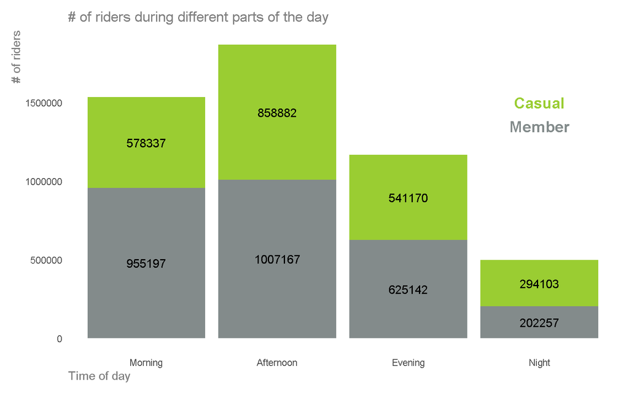

```r
time_of_day %>%
  ggplot(aes(x = factor(ride_part_of_the_day, levels = c("Morning", "Afternoon", "Evening", "Night")), fill = member_casual)) +
  geom_bar() +
  scale_fill_manual(values = c("olivedrab3", "azure4")) +
  labs(title = "# of riders during different parts of the day") +
  theme(axis.title.x = element_text(hjust = 0),
        axis.title.y = element_text(hjust = 1),
        axis.ticks.x = element_blank(),
        axis.ticks.y = element_blank(),
        legend.position = "none",
        panel.background = element_blank(),
        axis.title = element_text(color = "#808080"),
        plot.title = element_text(color = "#808080"),
        plot.margin = margin(t = 10, b = 10, l = 10, r = 10)) +
  ylab("# of riders") +
  xlab("Time of day") +
  geom_text(stat = "count", aes(label = ..count..), position = position_stack(vjust = .5), color = "black") +
  annotate("text", x = 4, y = 1500000, label = "Casual", color = "olivedrab3", size = 5, fontface = 2) +
  annotate("text", x = 4, y = 1350000, label = "Member", color = "azure4", size = 5, fontface = 2)
```

The afternoon (1:00 p.m. to 5:00 p.m) has the peak # of riders while the nighttime (10:00 p.m. to 4:00 a.m) has the least amount of riders.

```r
weekly_distribution <- dbGetQuery(con,
            "SELECT
              FORMAT_DATE('%a', date_started) as day_of_week,
              FORMAT_DATE('%b', date_started) as month_started,
              member_casual,
              COUNT(*) as count
             FROM
              `portfolio-projects-338303.cyclist_trip.2021_divvy_tripdata`
              GROUP BY day_of_week, month_started, member_casual
              ORDER BY
              CASE
                  WHEN month_started = 'Jan' THEN 1
                  WHEN month_started = 'Feb' THEN 2
                  WHEN month_started = 'Mar' THEN 3
                  WHEN month_started = 'Apr' THEN 4
                  WHEN month_started = 'May' THEN 5
                  WHEN month_started = 'Jun' THEN 6
                  WHEN month_started = 'Jul' THEN 7
                  WHEN month_started = 'Aug' THEN 8
                  WHEN month_started = 'Sep' THEN 9
                  WHEN month_started = 'Oct' THEN 10
                  WHEN month_started = 'Nov' THEN 11
                  WHEN month_started = 'Dec' THEN 12
                      END ASC ")
```

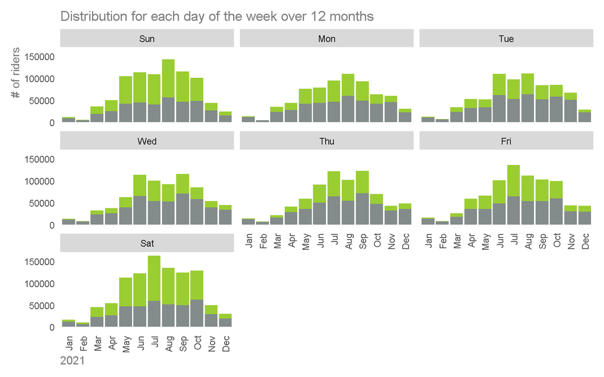

```r
weekly_distribution %>%
  ggplot(aes(x = factor(month_started, levels = unique(month_started)), y = count, fill = member_casual)) +
  geom_bar(stat = "identity") +
  facet_wrap(~factor(day_of_week, levels = c("Sun","Mon", "Tue", "Wed", "Thu", "Fri", "Sat"))) +
  labs(title = "Distribution for each day of the week over 12 months") +
  theme(axis.title.x = element_text(hjust = 0),
        axis.title.y = element_text(hjust = 1),
        axis.ticks.x = element_blank(),
        axis.ticks.y = element_blank(),
        legend.position = "none",
        panel.background = element_blank(),
        axis.text.x = element_text(angle = 90, vjust = .5, hjust = 1),
        axis.title = element_text(color = "#808080"),
        plot.title = element_text(color = "#808080"),
        plot.margin = margin(t = 10, b = 10, l = 10, r = 10)) +
  scale_fill_manual(values = c("olivedrab3", "azure4")) +
  xlab("2021") +
  ylab("# of riders")
```

For all days in the week, there is a fairly normal, bell-shaped curve to our distributions. There are a low # of riders at the beginning of the year when it’s cold and once summer comes around, there are more riders.

# Recommendations for marketing strategy

1. Offer **promotional deals** for trips that cover **more distance** for member riders.
2. Offer **promotional deals** for trips during the period of June and July for member riders.
3. Highlight more **bicycling races/fundraisers** throughout the year.